# Analysis on YouTube Trending Video Statistics Dataset

## Goal of analysis

using YouTube trending video statistics dataset and analyzing in different ways such as

• How long usually a video can trend in different countries? • How many likes, dislikes, views and comments get by different countries? • How are views, likes, dislikes, comment count, title length, and other attributes correlate with (relate to) each other? How are they connected? • Correlation of trending video in between countries. • Videos from which category has longer trend? • Users like videos from which category the most? • What is the ratio of Likes-Dislikes and Views-Comments in different categories? • What's the tags in the most negative and most positive category? What's the most discuss words for Science & Technology? etc.

## Background

YouTube is the most popular and most used video platform in the world today. YouTube has a list of trending videos that is updated constantly. Here I will use Python with some packages like Pandas and Matplotlib to analyze a dataset and represent observation via different graph. The dataset contains data more than 40,000 trending videos. I will analyze this data to get insights into YouTube trending videos, to see what is common between these videos. Those insights might also be used by YouTube creators who want to increase popularity of their videos on YouTube. This dataset includes several months of data on daily trending YouTube videos. Data is included for the USA, Great Britain, Germany, Canada, and France etc.., with up to 200 listed trending videos per day. Each region’s data is in a separate file. Data includes the video title, channel title, publish time, tags, views, likes and dislikes, description, and comment count. The data also includes a “category_id” field, which varies between regions which can be retrieved by respective JSON files.

Loading of data

```python
import glob
import datetime
import pandas as pd
import matplotlib.pyplot as plt; plt.rcdefaults()
%matplotlib inline
import seaborn as sns
import numpy as np
import pylab as pl
from PIL import Image
from wordcloud import STOPWORDS,WordCloud

df=[]
df=(glob.glob('*.csv'))
print(df)
```

```
['Canada.csv', 'France.csv', 'Germany.csv', 'USA.csv']
```

```python
Countries = []

for i in range(len(df)):
    Countries.append(pd.read_csv(df[i]))
```

Check collected data

```
Canada
```

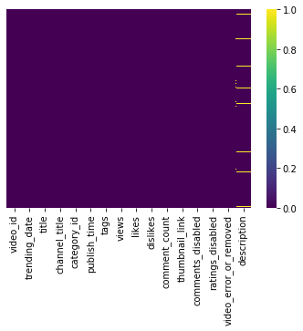

```python
print("Canada")
sns.heatmap(Countries[0].isnull(),yticklabels=False,cbar=True,cmap='viridis')
```

[output not shown]

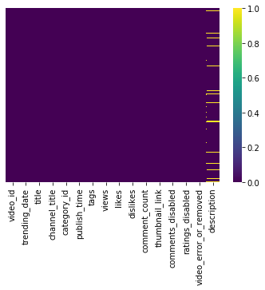

```python
print("Germany")
sns.heatmap(Countries[1].isnull(),yticklabels=False,cbar=True,cmap='viridis')
```

[output not shown]

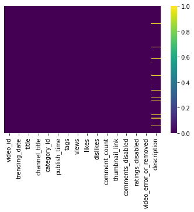

```python
print("France")
sns.heatmap(Countries[2].isnull(),yticklabels=False,cbar=True,cmap='viridis')
```

```
USA
```

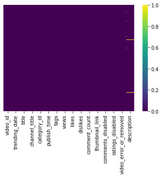

```python
print("USA")
sns.heatmap(Countries[3].isnull(),yticklabels=False,cbar=True,cmap='viridis')
```

```python
# Get column names

Countries_column=[]

for i in range(len(df)):
    Countries_column.append(pd.read_csv(df[i]).columns)
    print(df[i]," : ")
    print(Countries_column[i])
    print("-----------------------------------------")


# Get column data types

Countries_datatypes=[]

for i in range(len(df)):
    Countries_datatypes.append(pd.read_csv(df[i]).dtypes)
    print(df[i]," : ")
    print(Countries_datatypes[i])
    print("-----------------------------------------")


#Check rows and column
for i in range(len(df)):
    print(df[i]," : ",Countries[i].shape)
    print("-----------------------------------------")
```

```
Canada.csv  :
Index(['video_id', 'trending_date', 'title', 'channel_title', 'category_id',
       'publish_time', 'tags', 'views', 'likes', 'dislikes', 'comment_count',
       'thumbnail_link', 'comments_disabled', 'ratings_disabled',
       'video_error_or_removed', 'description'],
      dtype='object')
-----------------------------------------
France.csv  :
Index(['video_id', 'trending_date', 'title', 'channel_title', 'category_id',
       'publish_time', 'tags', 'views', 'likes', 'dislikes', 'comment_count',
       'thumbnail_link', 'comments_disabled', 'ratings_disabled',
       'video_error_or_removed', 'description'],
      dtype='object')
-----------------------------------------
Germany.csv  :
Index(['video_id', 'trending_date', 'title', 'channel_title', 'category_id',
       'publish_time', 'tags', 'views', 'likes', 'dislikes', 'comment_count',
       'thumbnail_link', 'comments_disabled', 'ratings_disabled',
       'video_error_or_removed', 'description'],
      dtype='object')
-----------------------------------------
USA.csv  :
Index(['video_id', 'trending_date', 'title', 'channel_title', 'category_id',
       'publish_time', 'tags', 'views', 'likes', 'dislikes', 'comment_count',
       'thumbnail_link', 'comments_disabled', 'ratings_disabled',
       'video_error_or_removed', 'description'],
      dtype='object')
-----------------------------------------
Canada.csv  :
video_id                  object
trending_date             object
title                     object
channel_title             object
category_id                int64
publish_time              object
tags                      object
views                      int64
likes                      int64
dislikes                   int64
comment_count              int64
```

[output cut: 57 more lines]

```
thumbnail_link            object
comments_disabled           bool
ratings_disabled            bool
video_error_or_removed      bool
description               object
dtype: object
-----------------------------------------
Canada.csv  :  (40881, 16)
-----------------------------------------
France.csv  :  (40724, 16)
-----------------------------------------
Germany.csv  :  (40840, 16)
-----------------------------------------
USA.csv  :  (40949, 16)
-----------------------------------------
```

```python
#Check unique rows

for i in range(len(df)):
    print(df[i]," : ")
    print(Countries[i].nunique())
    print("-----------------------------------------")
```

```
Canada.csv  :
video_id                  24427
trending_date               205
title                     24573
channel_title              5076
category_id                  17
publish_time              23613
tags                      20157
views                     40170
likes                     24676
dislikes                   6241
comment_count             11172
thumbnail_link            24422
comments_disabled             2
ratings_disabled              2
video_error_or_removed        2
description               22345
dtype: int64
-----------------------------------------
France.csv  :
video_id                  30581
trending_date               205
title                     30544
channel_title              6680
category_id                  18
publish_time              29234
tags                      22903
views                     36442
likes                     15618
dislikes                   3736
comment_count              5832
thumbnail_link            30572
comments_disabled             2
ratings_disabled              2
video_error_or_removed        2
description               25002
dtype: int64
-----------------------------------------
Germany.csv  :
video_id                  29627
```

[output cut: 21 more lines]

```
channel_title              2207
category_id                  16
publish_time               6269
tags                       6055
views                     40478
likes                     29850
dislikes                   8516
comment_count             13773
thumbnail_link             6352
comments_disabled             2
ratings_disabled              2
video_error_or_removed        2
description                6901
dtype: int64
-----------------------------------------
```

```python
#Check null rows

for i in range(len(df)):
    print(df[i]," : ")
    print(Countries[i].isnull().sum())
    print("-----------------------------------------")
```

```
Canada.csv  :
video_id                     0
trending_date                0
title                        0
channel_title                0
category_id                  0
publish_time                 0
tags                         0
views                        0
likes                        0
dislikes                     0
comment_count                0
thumbnail_link               0
comments_disabled            0
ratings_disabled             0
video_error_or_removed       0
description               1296
dtype: int64
-----------------------------------------
France.csv  :
video_id                     0
trending_date                0
title                        0
channel_title                0
category_id                  0
publish_time                 0
tags                         0
views                        0
likes                        0
dislikes                     0
comment_count                0
thumbnail_link               0
comments_disabled            0
ratings_disabled             0
video_error_or_removed       0
description               2912
dtype: int64
-----------------------------------------
Germany.csv  :
video_id                     0
```

[output cut: 21 more lines]

```
channel_title               0
category_id                 0
publish_time                0
tags                        0
views                       0
likes                       0
dislikes                    0
comment_count               0
thumbnail_link              0
comments_disabled           0
ratings_disabled            0
video_error_or_removed      0
description               570
dtype: int64
-----------------------------------------
```

So, we have some null value in 'description' column in all countries data files

```python
#Filling the null values with space (" ")

Countries_modified=[]

for i in range(len(df)):
    Countries_modified.append(Countries[i].fillna(" "))
    print(df[i]," : ")
    print(Countries_modified[i].isnull().sum())
    print("-----------------------------------------")
```

```
Canada.csv  :
video_id                  0
trending_date             0
title                     0
channel_title             0
category_id               0
publish_time              0
tags                      0
views                     0
likes                     0
dislikes                  0
comment_count             0
thumbnail_link            0
comments_disabled         0
ratings_disabled          0
video_error_or_removed    0
description               0
dtype: int64
-----------------------------------------
France.csv  :
video_id                  0
trending_date             0
title                     0
channel_title             0
category_id               0
publish_time              0
tags                      0
views                     0
likes                     0
dislikes                  0
comment_count             0
thumbnail_link            0
comments_disabled         0
ratings_disabled          0
video_error_or_removed    0
description               0
dtype: int64
-----------------------------------------
Germany.csv  :
video_id                  0
```

[output cut: 21 more lines]

```
channel_title             0
category_id               0
publish_time              0
tags                      0
views                     0
likes                     0
dislikes                  0
comment_count             0
thumbnail_link            0
comments_disabled         0
ratings_disabled          0
video_error_or_removed    0
description               0
dtype: int64
-----------------------------------------
```

```python
print("Canada")
sns.heatmap(Countries_modified[0].isnull(),yticklabels=False,cbar=True,cmap='viridis')
```

[output not shown]

```
Canada
```

```python
print("Germany")
sns.heatmap(Countries_modified[1].isnull(),yticklabels=False,cbar=True,cmap='viridis')
```

[output not shown]

```
Germany
```

```python
print("France")
sns.heatmap(Countries_modified[2].isnull(),yticklabels=False,cbar=True,cmap='viridis')
```

[output not shown]

```
France
```

```python
print("USA")
sns.heatmap(Countries_modified[3].isnull(),yticklabels=False,cbar=True,cmap='viridis')
```

[output not shown]

```
USA
```

Now data is clean. We will proceed with analysis

### Number of Video created in all the countries

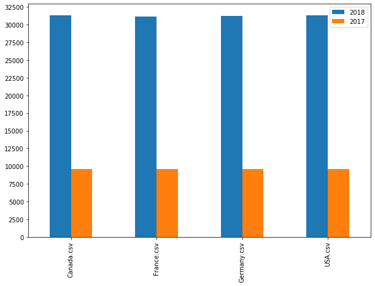

```python
Countries_modified
temp_list={}
for i in range(len(df)):
    temp_list[df[i]]=list(Countries_modified[i]["trending_date"].apply(lambda x: '20' + x[:2]).value_counts())


temp_df=pd.DataFrame(temp_list).T
temp_df.columns = ['2018','2017']
temp_df

temp_df.plot(kind="bar", yticks = range(0,35000,2500), figsize=(10,7))
```

### Video category created most in all countries

```
{'Canada.csv': {'[24]': 13451}, 'France.csv': {'[24]': 9819}, 'Germany.csv': {'[24]': 15292}, 'USA.csv': {'[24]': 9964}}
```

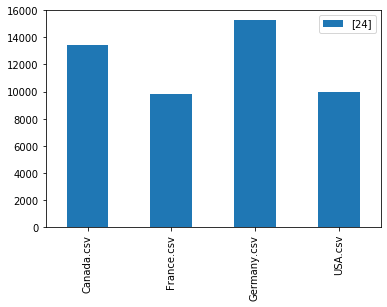

```python
t=[pd.DataFrame for i in range(len(df))]
l1=[]
l2=[]
dict1={}
No_of_videos_category = {}

for i in range(len(df)):
    t[i]=Countries_modified[i].groupby('category_id').count()
    l1.append(str(list(t[i][['video_id']].idxmax())))
    l2.append(t[i].video_id.max())

dict1= {}
for i in range(len(df)):
    dict1.update({df[i]:{l1[i]:l2[i]}})


print(dict1)

plot2 = pd.DataFrame(dict1).T

plot2.plot(kind="bar", stacked=True)
plt.show()
```

### Time range when most videos are uploaded

```python
li={}

for i in range(len(Countries_modified)):
    list123=[]
    for j in range(Countries_modified[i].publish_time.count()):
        d2= datetime.datetime.strptime(str(Countries_modified[i].publish_time[j]),"%Y-%m-%dT%H:%M:%S.%fZ")
        new_format = "%Y-%m-%d"
        d2.strftime(new_format)
        list123.append(d2.hour)

    li.update({df[i]:list123})
    Countries_modified[i]['publish_timestamp']=list123

#Countries_modified[0].publish_date
#Countries_modified[0].publish_timestamp
```

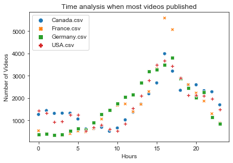

```python
test=[pd.DataFrame for i in range(len(Countries_modified))]
test2 = pd.DataFrame()

for i in range(len(Countries_modified)):
    test[i]=Countries_modified[i].groupby('publish_timestamp').count()
    test[i]=test[i].nlargest(10000,'video_id')
    test2[df[i]]=test[i]['video_id']


ax=sns.scatterplot(data=test2)
sns.set_style("ticks",{"xtick.major.size":8,"ytick.major.size":8})
#sns.axes_style("whitegrid")
ax.set(xlabel='Hours', ylabel='Number of Videos',title= 'Time analysis when most videos published')
#plt.tight_layout()
plt.show()
```

Creating word cloud for each category

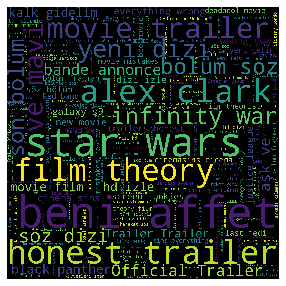

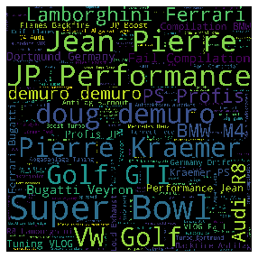

```python
l1=[]
l2=[]
for i in range(len(Countries_modified)):
        #wordcloud_df.insert(,Countries_modified[i].category_id,Countries_modified[i].tags)
        l1.append(Countries_modified[i].category_id)
        l2.append(list(Countries_modified[i].tags))
#print(l1)
flat_list1 = []
flat_list2= []
for sublist in l1:
    for item in sublist:
        flat_list1.append(item)
for sublist in l2:
    for item in sublist:
        flat_list2.append(item)



wc_df = pd.DataFrame({'Category_id_total': flat_list1,'tag_total': flat_list2})
#print(wc_df['Category_id_total'].nunique()) to check unique values
wcg_df=pd.DataFrame(wc_df.groupby('Category_id_total')['tag_total'].apply('|'.join))
print(wcg_df.head())

for i in range(2):                                   #int(wcg_df.count())
    text= wcg_df['tag_total'].iloc[i]
    wordcloud1 = WordCloud(
        width = 3000,
        height = 3000,
        background_color = 'black',
        stopwords = STOPWORDS).generate(str(text))
    plt.figure(figsize=(15,5))
    plt.imshow(wordcloud1)
    plt.axis('off')
```